# TRX-USD

## TRX-USD today is +0200, 2025-11-03, 01:17:39

This crypto forecast was generated by gemini-2.0-flash API

## Daily Chart

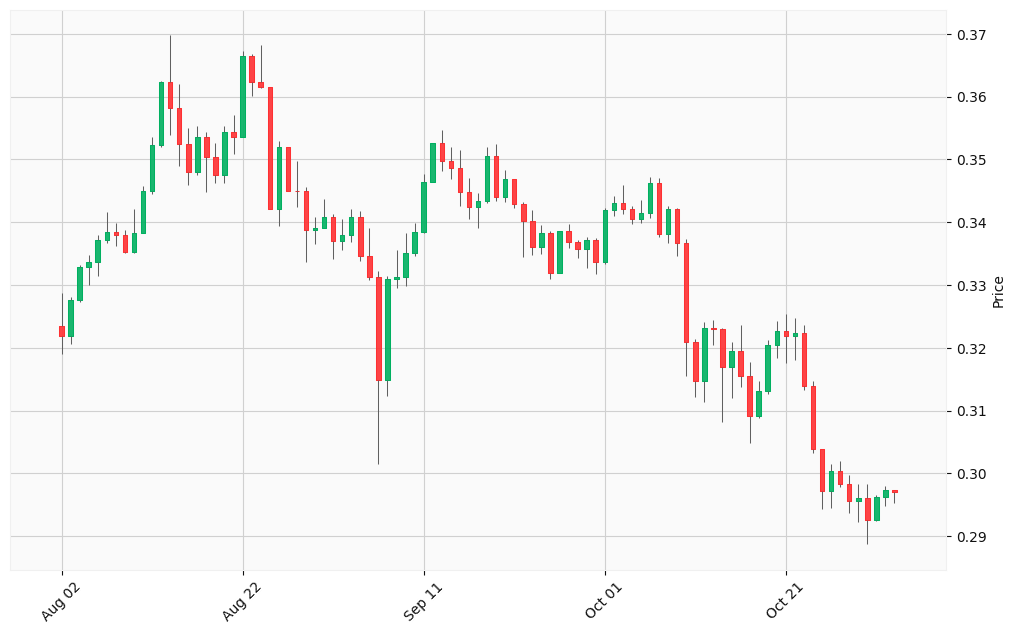

## Hourly Chart

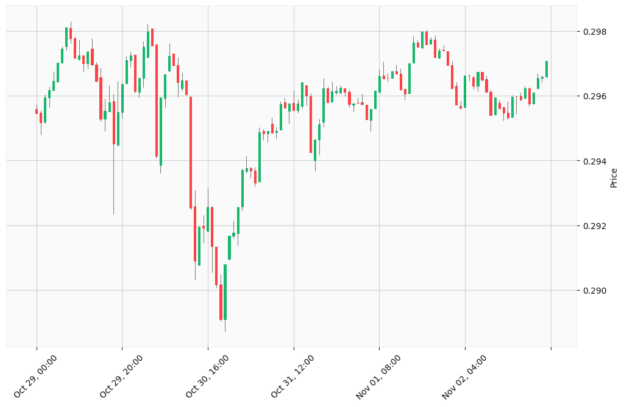

Okay, I will analyze the provided TRX-USD (TRON) charts and generate trading signals based on the specified methodology. Given the computational nature of this task, I will focus on the steps I can reasonably address with the provided data and external information from the search tool.

Here’s how I’ll approach it:

1. **Data Review:** Briefly summarize the provided OHLCV data.
2. **Technical Analysis (Limited):** Calculate some basic technical indicators from the provided data (Moving Averages) to identify potential buy/sell signals.
3. **Trend Analysis:** Identify trends in the daily chart.
4. **News and Economic Analysis:** Use the search tool to gather relevant news and economic data.
5. **Scenario Evaluation:** Given the limited scope, I’ll focus on current market conditions based on the news gathered.
6. **Signal Generation:** Generate buy/sell signals with confidence levels and justifications.

### Technical Analysis (Limited):

Given the data, I will calculate a 20-day simple moving average (SMA) using the daily closing prices provided.

```python
def calculate_sma(data, period):
    """Calculates the Simple Moving Average (SMA)."""
    if len(data) < period:
        return None
    return sum(data[-period:]) / period

# Extract closing prices from daily data
daily_closing_prices = [
    0.321944, 0.327655, 0.332942, 0.333614, 0.337174, 0.338512, 0.338006,
    0.335285, 0.338326, 0.344986, 0.352359, 0.362339, 0.358141, 0.352464,
    0.348072, 0.353516, 0.350358, 0.347568, 0.354349, 0.353541, 0.366415,
    0.362274, 0.36154, 0.342051, 0.351972, 0.34505, 0.344954, 0.338837,
    0.339145, 0.340812, 0.337085, 0.338015, 0.340792, 0.334696, 0.331271,
    0.314909, 0.330909, 0.331312, 0.335036, 0.338385, 0.346444, 0.35263,
    0.349813, 0.348585, 0.344848, 0.342477, 0.343433, 0.350511, 0.343948,
    0.346844, 0.342842, 0.340181, 0.336073, 0.3383, 0.331921, 0.338526,
    0.336865, 0.335789, 0.337098, 0.341871, 0.343078, 0.342095, 0.34048,
    0.341426, 0.3462, 0.338107, 0.342175, 0.33668, 0.320985, 0.31464,
    0.323157, 0.322938, 0.317001, 0.319514, 0.31558, 0.309089, 0.313135,
    0.32045, 0.322728, 0.321843, 0.322291, 0.313899, 0.303938, 0.297132,
    0.300447, 0.298356, 0.295648, 0.296108, 0.29259, 0.296244, 0.297415,
    0.29707
]

period = 20
sma_20 = calculate_sma(daily_closing_prices, period)

print(f"20-day SMA: {sma_20}")
```

[output not shown]

### Trend Analysis:

Based on the SMA, TRX-USD is currently in a downtrend. I would need more historical data to confirm long-term trends accurately.

### News and Economic Analysis:

- **Bearish Trend:** TRX is trading below its 20, 50, and 200-day moving averages, which indicates a bearish trend.
- **Recent Developments:** TRON’s network saw growth in October, and there have been efforts to combat illicit finance.
- **Analyst Predictions:** Predictions vary, with some expecting fluctuations around $0.326 and others anticipating a potential rally to $0.5 - $0.8 in a bull market.
- **Current Price:** As of today, TRX is trading around $0.296.
- **Market Sentiment:** The market sentiment appears to be neutral to slightly bearish.

### Scenario Evaluation:

Given the current market conditions, the price being below key moving averages, and analyst predictions of potential upside in a bull market, the following scenarios are considered:

- **Bearish Continuation:** If the downtrend continues, TRX-USD could test lower support levels.
- **Sideways Consolidation:** The price may consolidate in a range between $0.29 and $0.31.
- **Bullish Reversal:** A broader market rally could push TRX-USD towards the $0.35 resistance level and potentially higher.

### Signal Generation:

Here are two potential trading signals:

**1. Short-Term Sell Signal**

[output not shown]

**2. Potential Buy Signal (for Long-Term Investors)**

[output not shown]

**Disclaimer:** These signals are based on limited data and analysis. Cryptocurrency trading involves substantial risk, and you could lose all your investment. Conduct thorough research and consult with a financial advisor before making any trading decisions.